# Data Camp Insights

```r
# Get revision history for "Hadley Wickham"
resp_json <- rev_history("Hadley Wickham")

# Check http_type() of resp_json
http_type(resp_json)

# Examine returned text with content()
content(resp_json, as="text")

# Parse response with content()
content(resp_json, as="parsed")

# Parse returned text with fromJSON()
library(jsonlite)
fromJSON(content(resp_json, as="text"))


# Load rlist
library(rlist)

# Examine output of this code
str(content(resp_json), max.level = 4)

# Store revision list
revs <- content(resp_json)$query$pages$`41916270`$revisions

# Extract the user element
user_time <- list.select(revs, user, timestamp)

# Print user_time
user_time

# Stack to turn into a data frame
list.stack(user_time)


# Load dplyr
library(dplyr)

# Pull out revision list
revs <- content(resp_json)$query$pages$`41916270`$revisions

# Extract user and timestamp
revs %>%
  bind_rows() %>%
  select(user, timestamp)


# Load xml2
library(xml2)

# Get XML revision history
resp_xml <- rev_history("Hadley Wickham", format = "xml")

# Check response is XML
http_type(resp_xml)

# Examine returned text with content()
rev_text <- content(resp_xml, as="text")
rev_text

# Turn rev_text into an XML document
rev_xml <- read_xml(rev_text)

# Examine the structure of rev_xml
str(rev_xml)


# Load xml2
library(xml2)

# Get XML revision history
resp_xml <- rev_history("Hadley Wickham", format = "xml")

# Check response is XML
http_type(resp_xml)

# Examine returned text with content()
rev_text <- content(resp_xml, as="text")
rev_text

# Turn rev_text into an XML document
rev_xml <- read_xml(rev_text)

# Examine the structure of rev_xml
xml_structure(rev_xml)


# Find all nodes using XPATH "/api/query/pages/page/revisions/rev"
xml_find_all(rev_xml, "/api/query/pages/page/revisions/rev")

# Find all rev nodes anywhere in document
rev_nodes <- xml_find_all(rev_xml, "//rev")

# Use xml_text() to get text from rev_nodes
xml_text(rev_nodes)


# All rev nodes
rev_nodes <- xml_find_all(rev_xml, "//rev")

# The first rev node
first_rev_node <- xml_find_first(rev_xml, "//rev")

# Find all attributes with xml_attrs()
xml_attrs(first_rev_node)

# Find user attribute with xml_attr()
xml_attr(first_rev_node, attr="user")

# Find user attribute for all rev nodes
xml_attr(rev_nodes, attr="user")

# Find anon attribute for all rev nodes
xml_attr(rev_nodes, attr="anon")


get_revision_history <- function(article_title){
  # Get raw revision response
  rev_resp <- rev_history(article_title, format = "xml")

  # Turn the content() of rev_resp into XML
  rev_xml <- read_xml(content(rev_resp, "text"))

  # Find revision nodes
  rev_nodes <- xml_find_all(rev_xml, "//rev")

  # Parse out usernames
  user <- xml_attr(rev_nodes, attr="user")

  # Parse out timestamps
  timestamp <- readr::parse_datetime(xml_attr(rev_nodes, "timestamp"))

  # Parse out content
  content <- xml_text(rev_nodes)

  # Return data frame
  data.frame(user = user,
    timestamp = timestamp,
    content = substr(content, 1, 40))
}

# Call function for "Hadley Wickham"
get_revision_history(article_title = "Hadley Wickham")
```

[output not shown]

Chapter 4 - Web Scraping with XPATH

Web scraping 101 - sometimes a website does not have an API, so a different approach is required:

- Web scraping is the process of grabbling the full html and then parsing the data as needed
- The “selector” plug-in for a browser can be helpful for finding IDs associated with examples of interest
- There is a package “rvest” that helps to simplify the process of web scraping
  - rvest::read_html(url=) # returns an XML document
  - html_node() will extract contents with XPATH (???) - the argument to html_node should be the returned XML document from the previous step

HTML structure - basically, content within tags, much like XML:

Reformatting data (especially to a rectangular format such as a data frame):

Example code includes:

```r
# Load rvest
library(rvest)
# Hadley Wickham's Wikipedia page
test_url <- "https://en.wikipedia.org/wiki/Hadley_Wickham"

# Read the URL stored as "test_url" with read_html()
test_xml <- read_html(test_url)

# Print test_xml
test_xml
```

```
## {xml_document}
## <html class="client-nojs" lang="en" dir="ltr">
## [1] <head>\n<meta http-equiv="Content-Type" content="text/html; charset= ...
## [2] <body class="mediawiki ltr sitedir-ltr mw-hide-empty-elt ns-0 ns-sub ...
```

```r
test_node_xpath <- "//*[contains(concat( \" \", @class, \" \" ), concat( \" \", \"vcard\", \" \" ))]"
# Use html_node() to grab the node with the XPATH stored as `test_node_xpath`
node <- html_node(x = test_xml, xpath = test_node_xpath)

# Print the first element of the result
node[1]
```

```
## $node
## <pointer: 0x000000000b91bb80>
```

```r
# The first thing we'll grab is a name, from the first element of the previously extracted table (now stored as table_element)
table_element <- node

# Extract the name of table_element
element_name <- html_name(table_element)

# Print the name
element_name
```

```
## [1] "table"
```

```r
second_xpath_val <- "//*[contains(concat( \" \", @class, \" \" ), concat( \" \", \"fn\", \" \" ))]"
# Extract the element of table_element referred to by second_xpath_val and store it as page_name
page_name <- html_node(x = table_element, xpath = second_xpath_val)

# Extract the text from page_name
page_title <- html_text(page_name)

# Print page_title
page_title
```

```
## [1] "Hadley Wickham"
```

```r
# Turn table_element into a data frame and assign it to wiki_table
wiki_table <- html_table(table_element)

# Print wiki_table
wiki_table
```

```
##       Hadley Wickham
## 1
## 2          Residence
## 3         Alma mater
## 4          Known for
## 5             Awards
## 6  Scientific career
## 7             Fields
## 8             Thesis
## 9  Doctoral advisors
## 10 Doctoral students
## 11
##                                                                       Hadley Wickham
## 1
## 2                                                                      United States
## 3                                      Iowa State University, University of Auckland
## 4                                                    R programming language packages
## 5  John Chambers Award (2006)\nFellow of the American Statistical Association (2015)
## 6                                                                  Scientific career
## 7                                 Statistics\nData science\nR (programming language)
## 8                               Practical tools for exploring data and models (2008)
## 9                                                             Di Cook\nHeike Hofmann
## 10                                                                 Garrett Grolemund
## 11
```

```r
# Rename the columns of wiki_table
colnames(wiki_table) <- c("key", "value")

# Remove the empty row from wiki_table
cleaned_table <- subset(wiki_table, !(key == ""))

# Print cleaned_table
cleaned_table
```

```
##                  key
## 2          Residence
## 3         Alma mater
## 4          Known for
## 5             Awards
## 6  Scientific career
## 7             Fields
## 8             Thesis
## 9  Doctoral advisors
## 10 Doctoral students
##                                                                                value
## 2                                                                      United States
## 3                                      Iowa State University, University of Auckland
## 4                                                    R programming language packages
## 5  John Chambers Award (2006)\nFellow of the American Statistical Association (2015)
## 6                                                                  Scientific career
## 7                                 Statistics\nData science\nR (programming language)
## 8                               Practical tools for exploring data and models (2008)
## 9                                                             Di Cook\nHeike Hofmann
## 10                                                                 Garrett Grolemund
```

Chapter 5 - CSS Web Scraping and Final Case Study

CSS (cascading style sheets) web scraping in theory:

Final case study: Introduction:

- Extracting an infobox from a Wikipedia page
  1. Get XML by way of API
  2. Extract infobox from the page
  3. Clean up and convert to data frame
  4. Wrap in a function for reproducibility

Wrap up:

- Downloading and reading flat files
- Designing and using API clients
- Web scraping using XPATHs and CSS

Example code includes:

```r
library(rvest)
# Hadley Wickham's Wikipedia page
test_url <- "https://en.wikipedia.org/wiki/Hadley_Wickham"

# Read the URL stored as "test_url" with read_html()
test_xml <- read_html(test_url)

# Print test_xml
test_xml
```

```
## {xml_document}
## <html class="client-nojs" lang="en" dir="ltr">
## [1] <head>\n<meta http-equiv="Content-Type" content="text/html; charset= ...
## [2] <body class="mediawiki ltr sitedir-ltr mw-hide-empty-elt ns-0 ns-sub ...
```

```r
# Select the table elements
html_nodes(test_xml, css = "table")
```

```
## {xml_nodeset (2)}
## [1] <table class="infobox biography vcard" style="width:22em">\n<tr>\n<t ...
## [2] <table class="nowraplinks hlist navbox-inner" style="border-spacing: ...
```

```r
# Select elements with class = "infobox"
html_nodes(test_xml, css = ".infobox")
```

```
## {xml_nodeset (1)}
## [1] <table class="infobox biography vcard" style="width:22em">\n<tr>\n<t ...
```

```r
# Select elements with id = "firstHeading"
html_nodes(test_xml, css = "#firstHeading")
```

```
## {xml_nodeset (1)}
## [1] <h1 id="firstHeading" class="firstHeading" lang="en">Hadley Wickham< ...
```

```r
# Extract element with class infobox
infobox_element <- html_nodes(test_xml, css = ".infobox")

# Get tag name of infobox_element
element_name <- html_name(infobox_element)

# Print element_name
element_name
```

```
## [1] "table"
```

```r
# Extract element with class fn
page_name <- html_node(x = infobox_element, css=".fn")

# Get contents of page_name
page_title <- html_text(page_name)

# Print page_title
page_title
```

```
## [1] "Hadley Wickham"
```

```r
# Load httr
library(httr)

# The API url
base_url <- "https://en.wikipedia.org/w/api.php"

# Set query parameters
query_params <- list(action="parse",
  page="Hadley Wickham",
  format="xml")

# Get data from API
resp <- GET(url = "https://en.wikipedia.org/w/api.php", query = query_params)

# Parse response
resp_xml <- content(resp)


# Load rvest
library(rvest)

# Read page contents as HTML
page_html <- read_html(xml_text(resp_xml))

# Extract infobox element
infobox_element <- html_node(page_html, css=".infobox")

# Extract page name element from infobox
page_name <- html_node(infobox_element, css=".fn")

# Extract page name as text
page_title <- html_text(page_name)


# Your code from earlier exercises
wiki_table <- html_table(infobox_element)
colnames(wiki_table) <- c("key", "value")
cleaned_table <- subset(wiki_table, !key == "")

# Create a dataframe for full name
name_df <- data.frame(key = "Full name", value = page_title)

# Combine name_df with cleaned_table
wiki_table2 <- rbind(name_df, cleaned_table)

# Print wiki_table
wiki_table2
```

```
##                  key
## 1          Full name
## 2          Residence
## 3         Alma mater
## 4          Known for
## 5             Awards
## 6  Scientific career
## 7             Fields
## 8             Thesis
## 9  Doctoral advisors
## 10 Doctoral students
##                                                                                value
## 1                                                                     Hadley Wickham
## 2                                                                      United States
## 3                                      Iowa State University, University of Auckland
## 4                                                    R programming language packages
## 5  John Chambers Award (2006)\nFellow of the American Statistical Association (2015)
## 6                                                                  Scientific career
## 7                                 Statistics\nData science\nR (programming language)
## 8                               Practical tools for exploring data and models (2008)
## 9                                                             Di Cook\nHeike Hofmann
## 10                                                                 Garrett Grolemund
```

```r
library(httr)
library(rvest)
library(xml2)

get_infobox <- function(title){
  base_url <- "https://en.wikipedia.org/w/api.php"

  # Change "Hadley Wickham" to title
  query_params <- list(action = "parse",
    page = title,
    format = "xml")

  resp <- GET(url = base_url, query = query_params)
  resp_xml <- content(resp)

  page_html <- read_html(xml_text(resp_xml))
  infobox_element <- html_node(x = page_html, css =".infobox")
  page_name <- html_node(x = infobox_element, css = ".fn")
  page_title <- html_text(page_name)

  wiki_table <- html_table(infobox_element)
  colnames(wiki_table) <- c("key", "value")
  cleaned_table <- subset(wiki_table, !wiki_table$key == "")
  name_df <- data.frame(key = "Full name", value = page_title)
  wiki_table <- rbind(name_df, cleaned_table)

  wiki_table
}

# Test get_infobox with "Hadley Wickham"
get_infobox(title = "Hadley Wickham")
```

```
##                  key
## 1          Full name
## 2          Residence
## 3         Alma mater
## 4          Known for
## 5             Awards
## 6  Scientific career
## 7             Fields
## 8             Thesis
## 9  Doctoral advisors
## 10 Doctoral students
##                                                                                value
## 1                                                                     Hadley Wickham
## 2                                                                      United States
## 3                                      Iowa State University, University of Auckland
## 4                                                    R programming language packages
## 5  John Chambers Award (2006)\nFellow of the American Statistical Association (2015)
## 6                                                                  Scientific career
## 7                                 Statistics\nData science\nR (programming language)
## 8                               Practical tools for exploring data and models (2008)
## 9                                                             Di Cook\nHeike Hofmann
## 10                                                                 Garrett Grolemund
```

```r
# Try get_infobox with "Ross Ihaka"
get_infobox(title = "Ross Ihaka")
```

```
##                                                 key
## 1                                         Full name
## 2  Ihaka at the 2010 New Zealand Open Source Awards
## 3                                         Residence
## 4                                        Alma mater
## 5                                         Known for
## 6                                            Awards
## 7                                 Scientific career
## 8                                            Fields
## 9                                      Institutions
## 10                                           Thesis
## 11                                 Doctoral advisor
##                                                       value
## 1                                                Ross Ihaka
## 2          Ihaka at the 2010 New Zealand Open Source Awards
## 3                                     Auckland, New Zealand
## 4  University of AucklandUniversity of California, Berkeley
## 5                                    R programming language
## 6                                    Pickering Medal (2008)
## 7                                         Scientific career
## 8                                     Statistical Computing
## 9                                    University of Auckland
## 10                                          Ruaumoko (1985)
## 11                                      David R. Brillinger
```

```r
# Try get_infobox with "Grace Hopper"
get_infobox(title = "Grace Hopper")
```

```
##                                   key
## 1                           Full name
## 2  Rear Admiral Grace M. Hopper, 1984
## 3                         Nickname(s)
## 4                                Born
## 5                                Died
## 6                     Place of burial
## 7                          Allegiance
## 8                      Service/branch
## 9                    Years of service
## 10                               Rank
## 11                             Awards
##                                                                                                                                                                                                                                                                                   value
## 1                                                                                                                                                                                                                                                                   Grace Murray Hopper
## 2                                                                                                                                                                                                                                                    Rear Admiral Grace M. Hopper, 1984
## 3                                                                                                                                                                                                                                                                       "Amazing Grace"
## 4                                                                                                                                                                                                                           (1906-12-09)December 9, 1906\nNew York City, New York, U.S.
## 5                                                                                                                                                                                                                        January 1, 1992(1992-01-01) (aged 85)Arlington, Virginia, U.S.
## 6                                                                                                                                                                                                                                                           Arlington National Cemetery
## 7                                                                                                                                                                                                                                                              United States of America
## 8                                                                                                                                                                                                                                                                    United States Navy
## 9                                                                                                                                                                                                                                                       19431966, 19671971, 19721986
## 10                                                                                                                                                                                                                                                            Rear admiral (lower half)
## 11 Defense Distinguished Service Medal Legion of Merit Meritorious Service Medal American Campaign Medal World War II Victory Medal National Defense Service Medal Armed Forces Reserve Medal with two Hourglass Devices Naval Reserve Medal Presidential Medal of Freedom (posthumous)
```

### *Data Visualization in R with lattice*

Chapter 1 - Basic plotting with lattice

Introduction - general objectives:

- Visualization may be for EDA or for reporting results
- Three basic graphing capabilities in R
  - Base - powerful but not flexible
  - lattice - based on “Trellis graphics” (Cleveland)
  - ggplot2 - based on “Grammar of Graphics” (Wilkinson)
- This course will cover lattice graphics for both EDA and reporting
- Focus will be on the USCancerRates dataset, with exploration of variance by gender and location
  - histogram(~ x, data=) # lattice for make a histogram (default appears to be RELATIVE frequency by bin)
  - xyplot(y ~ x, data=) # lattice for make an xy plot
  - The modeling calls are similar to what would be seen in an lm()

Optional arguments:

Box and whisker plots and reordering elements:

- Box and whisker plots are formed using bwplot(~ x, data=)
- Can serve a similar purpose as a histogram or density plot, and the formula is correspondingly similar
  - bwplot(y ~ x, data=) will make box plots for x, split by each level of y (which needs to be a factor/categorical)
- The function reorder(myFactor, myData, myFunction, . ) will reorder factor variables for plotting
  - For example, reorder(state, rate.male, median, na.rm=TRUE) will order the factor variable state by median(rate.male) in that state
- Your task for this exercise is to produce a box-and-whisker plot where the whiskers extend to the data extremes
  - These calculations are controlled by the coef argument of the R helper function boxplot.stats()
  - A positive value of coef makes the whiskers extend to no more than coef times the length of the box
  - The value of coef = 0 makes the whiskers extend to the data extremes

Example code includes:

```r
data(airquality)
str(airquality)
```

```
## 'data.frame':    153 obs. of  6 variables:
##  $ Ozone  : int  41 36 12 18 NA 28 23 19 8 NA ...
##  $ Solar.R: int  190 118 149 313 NA NA 299 99 19 194 ...
##  $ Wind   : num  7.4 8 12.6 11.5 14.3 14.9 8.6 13.8 20.1 8.6 ...
##  $ Temp   : int  67 72 74 62 56 66 65 59 61 69 ...
##  $ Month  : int  5 5 5 5 5 5 5 5 5 5 ...
##  $ Day    : int  1 2 3 4 5 6 7 8 9 10 ...
```

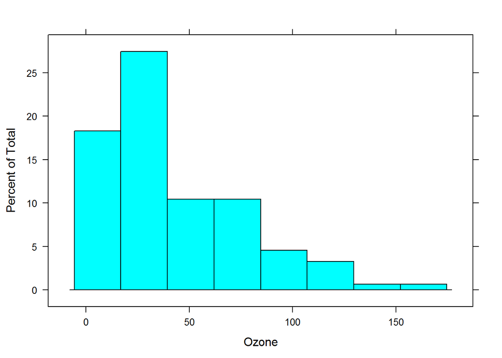

```r
# Load the lattice package
library(lattice)


# Create the histogram
histogram(~ Ozone, data = airquality)
```

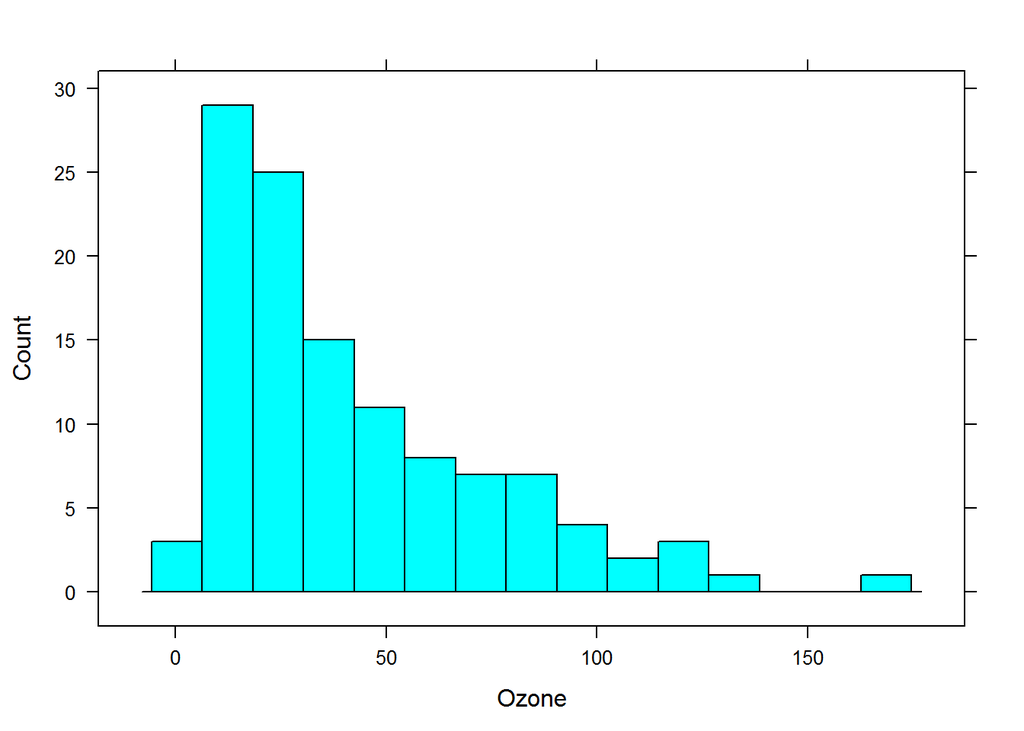

```r
# Create the histogram
histogram(~ Ozone, data = airquality,
          # Specify number of bins
          nint = 15,
          # Specify quantity displayed on y-axis
          type = "count")
```

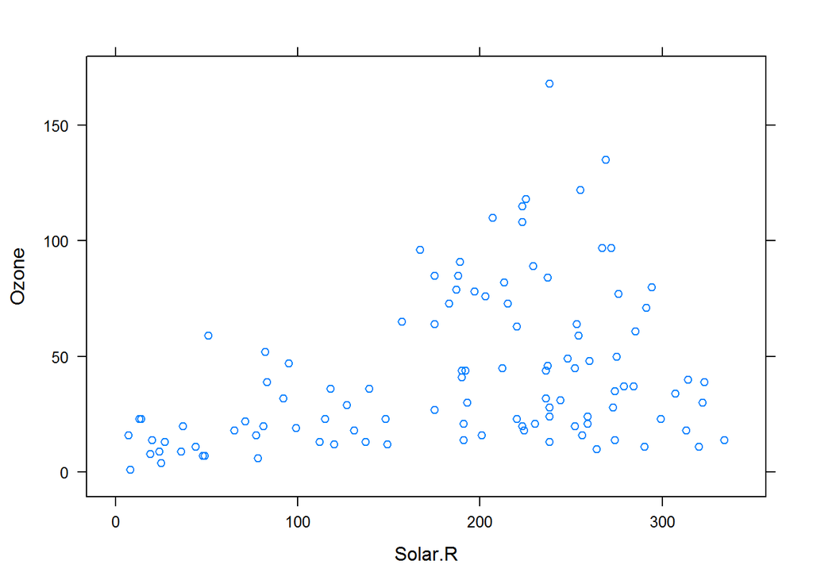

```r
# Create the scatter plot
xyplot(Ozone ~ Solar.R, data = airquality)
```

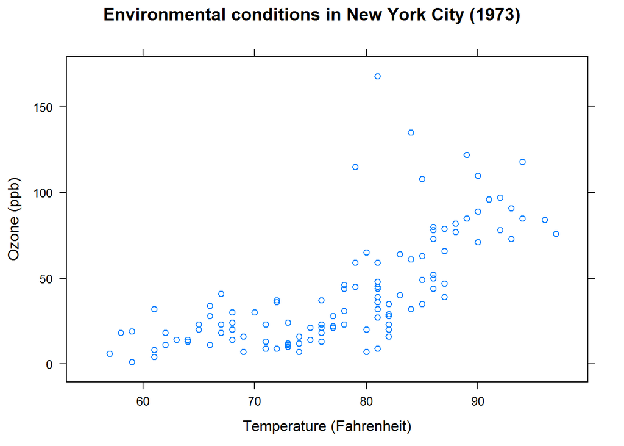

```r
# Create scatterplot
xyplot(Ozone ~ Temp, data = airquality,
       # Add main label
       main = "Environmental conditions in New York City (1973)",
       # Add axis labels
       ylab = "Ozone (ppb)",
       xlab = "Temperature (Fahrenheit)")
```

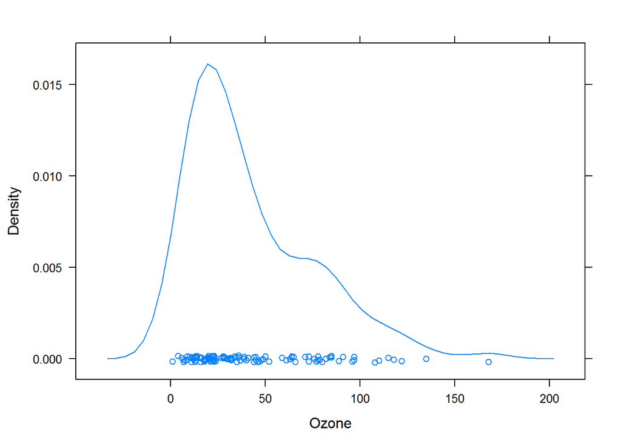

```r
# Create a density plot
densityplot(~ Ozone, data = airquality,
    # Choose how raw data is shown
    plot.points = "jitter")
```

```r
data(USCancerRates, package="latticeExtra")
str(USCancerRates)
```

```
## 'data.frame':    3041 obs. of  8 variables:
##  $ rate.male   : num  364 346 341 336 330 ...
##  $ LCL95.male  : num  311 274 304 289 293 ...
##  $ UCL95.male  : num  423 431 381 389 371 ...
##  $ rate.female : num  151 140 182 185 172 ...
##  $ LCL95.female: num  124 103 161 157 151 ...
##  $ UCL95.female: num  184 190 206 218 195 ...
##  $ state       : Factor w/ 49 levels "Alabama","Alaska",..: 1 1 1 1 1 1 1 1 1 1 ...
##  $ county      :Class 'AsIs'  chr [1:3041] "Pickens County" "Bullock County" "Russell County" "Barbour County" ...
```

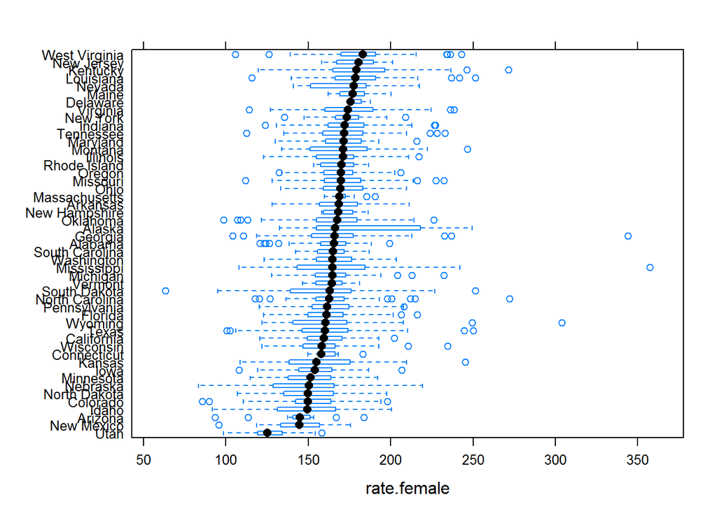

```r
rn_USCR <- row.names(USCancerRates)

# Create reordered variable
library(dplyr)
USCancerRates <-
    mutate(USCancerRates,
           state.ordered = reorder(state, rate.female, median, na.rm = TRUE)
           )

# Create box and whisker plot
bwplot(state.ordered ~ rate.female, data = USCancerRates)
```

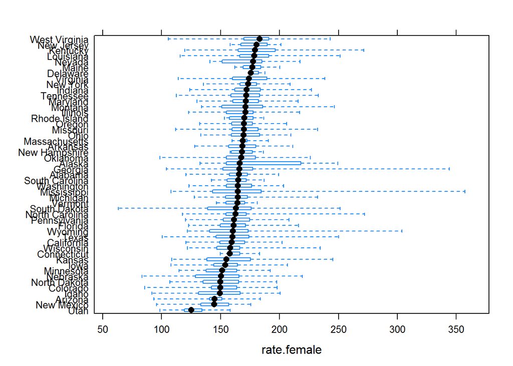

```r
# Create box and whisker plot
bwplot(state.ordered ~ rate.female, data = USCancerRates,
       # Change whiskers extent
       coef = 0)
```

Chapter 2 - Conditioning and the Formula Interface

Conditioning - identify sources of variability in the data by examining sub-groups:

- Small multiple design - conditioning/faceting approach
- The conditioning operator in lattice is the single-pipe (|)
  - xyplot(y ~ x | c, data=) # co is the conditioning variable in this example
  - Can use the conditioning operator in any function within the lattice framework
- The plus (+) operator is another way to condition - means condition on more than one variable
  - histogram(~ a + b, outer=TRUE, layout=c(1, 2), data=) will put a separate histogram for b below the separate histogram for a, keeping both on the same scale
  - The outer command determines how to interpret a+b
  - The layout=c(1, 2) means 1 column and 2 rows - general format is layout=c(ncol, nrow, npages)
- Since count-based functions tend to have higher variances associated to higher means, the log transform for these can be valuable
- lattice, unlike ggplot2, allows you to have data in a wide format

Data summary and transformation - grouping:

- Data summarization can be especially valuable for reporting
  - For example, may want to summarize cancer rates by state (median county) rather than by county
  - The tapply() function can be valuable for applying a function across a vector
  - To get both genders on the same plot but in different colors, use xyplot(State ~ Rate, data=, grid=TRUE, groups=Gender) # will treat the Gender as a separate group with different color on the same plot
- New concept: groups - interpreted as a factor that defines sub-groups
  - xyplot() and densityplot() support this, while histogram() does not
  - Using auto.key = TRUE will add a legend telling which colors are associated to which groups
- For more detailed control, the auto.key argument can be a list with various sub-components, the most useful of which are
  - space: which can be “left”, “right”, “top”, or “bottom”
  - columns: specifies the number of columns in which to divide up the levels
  - title: specifies a title for the legend

Incorporating external data sources:

- Can potentially split panels in to multiple pages or place multiple plots in the same pane
  - For eample, could aggregate states by region and report states in the same region together
  - The layout argument inside a lattice plotting function calls for layout=c(ncol, nrow)
  - The between argument inside a lattice plotting function calls for spacing - bewteen=list(y=c(0, 0, 1, 0, 0)) will put a space of 1 between the third and fourth items
- The outer=FALSE makes the conditioning variable in to a grouping variable - more effective visual with multiple plots together on the same pane
- In a conditioned lattice plot, the panels are by default drawn starting from the bottom-left position, going right and then up
  - This is patterned on the Cartesian coordinate system where the x-axis increases to the right and the y-axis increases from bottom to top
- Often, want to change this so that the layout is similar to a matrix or table, where rows start at the top
  - The layout of any conditioned lattice plot can be changed to follow this scheme by adding the optional argument as.table = TRUE

The trellis object - lattice creates trellis objects rather than directly creating plots (as in base R):

- Can run the class(), summary() and the like, with auto-print and/or print() making the plot visible
- If you have a trellis object, the update() command can be used to modify the object
  - In particular, their dimnames() are used as strip labels
- Can think of the trellis object as being like a matrix, so t(trellisObject) will flip the rows/columns
- Depending on the amount of space available, a conditioned plot may have too many combinations to be displayed effectively
  - Such plots can be split into multiple pages using the layout argument
  - But another convenient way to explore large lattice plots is to subset them like a matrix or array, using the [ indexing operator, to display only parts of the plot at a time

Example code includes:

```r
# The airquality dataset has been pre-loaded
str(airquality)
```

```
## 'data.frame':    153 obs. of  6 variables:
##  $ Ozone  : int  41 36 12 18 NA 28 23 19 8 NA ...
##  $ Solar.R: int  190 118 149 313 NA NA 299 99 19 194 ...
##  $ Wind   : num  7.4 8 12.6 11.5 14.3 14.9 8.6 13.8 20.1 8.6 ...
##  $ Temp   : int  67 72 74 62 56 66 65 59 61 69 ...
##  $ Month  : int  5 5 5 5 5 5 5 5 5 5 ...
##  $ Day    : int  1 2 3 4 5 6 7 8 9 10 ...
```

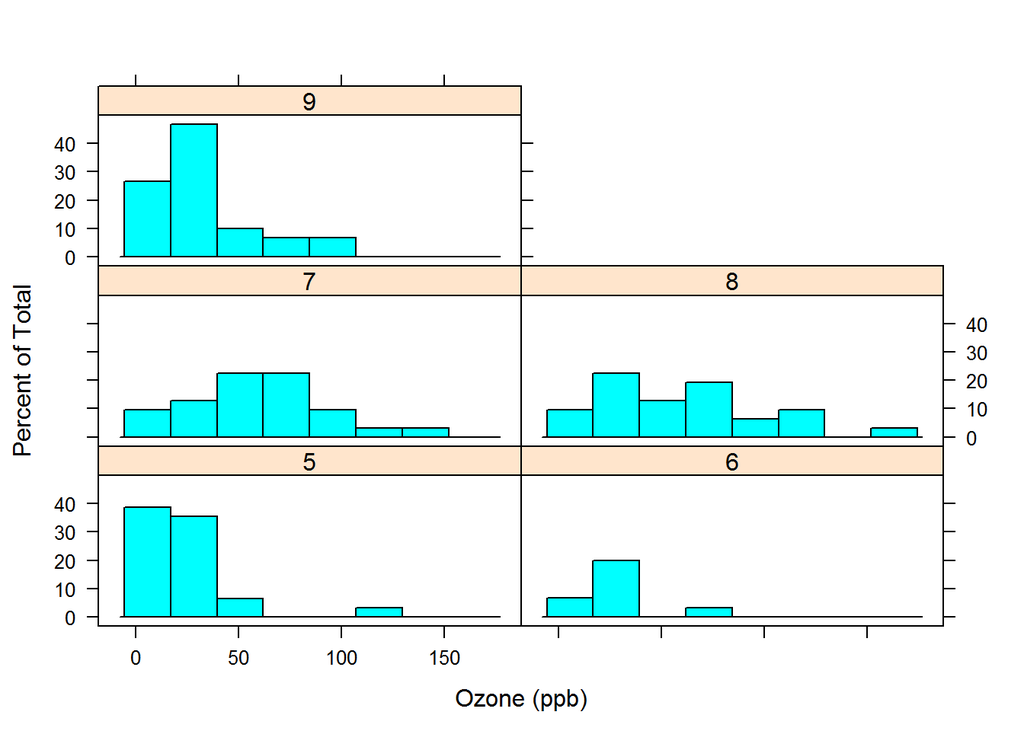

```r
# Create a histogram
histogram(~ Ozone | factor(Month),
          data = airquality,
          # Define the layout
          layout=c(2, 3),
          # Change the x-axis label
          xlab="Ozone (ppb)")
```

```r
# USCancerRates has been pre-loaded
str(USCancerRates)
```

```
## 'data.frame':    3041 obs. of  9 variables:
##  $ rate.male    : num  364 346 341 336 330 ...
##  $ LCL95.male   : num  311 274 304 289 293 ...
##  $ UCL95.male   : num  423 431 381 389 371 ...
##  $ rate.female  : num  151 140 182 185 172 ...
##  $ LCL95.female : num  124 103 161 157 151 ...
##  $ UCL95.female : num  184 190 206 218 195 ...
##  $ state        : Factor w/ 49 levels "Alabama","Alaska",..: 1 1 1 1 1 1 1 1 1 1 ...
##  $ county       :Class 'AsIs'  chr [1:3041] "Pickens County" "Bullock County" "Russell County" "Barbour County" ...
##  $ state.ordered: Factor w/ 49 levels "Utah","New Mexico",..: 25 25 25 25 25 25 25 25 25 25 ...
##   ..- attr(*, "scores")= num [1:49(1d)] 166 166 145 169 159 ...
##   .. ..- attr(*, "dimnames")=List of 1
##   .. .. ..$ : chr  "Alabama" "Alaska" "Arizona" "Arkansas" ...
```

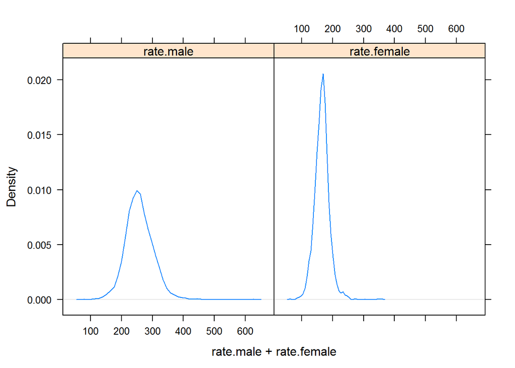

```r
# Create a density plot
densityplot(~ rate.male + rate.female,
    data = USCancerRates,
    outer = TRUE,
    # Suppress data points
    plot.points = FALSE,
    # Add a reference line
    ref=TRUE)
```

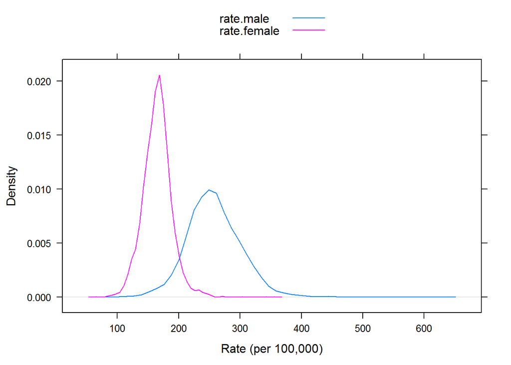

```r
# Create a density plot
densityplot(~ rate.male + rate.female,
    data = USCancerRates,
    # Set value of 'outer'
    outer=FALSE,
    # Add x-axis label
    xlab="Rate (per 100,000)",
    # Add a legend
    auto.key=TRUE,
    plot.points = FALSE,
    ref = TRUE)
```

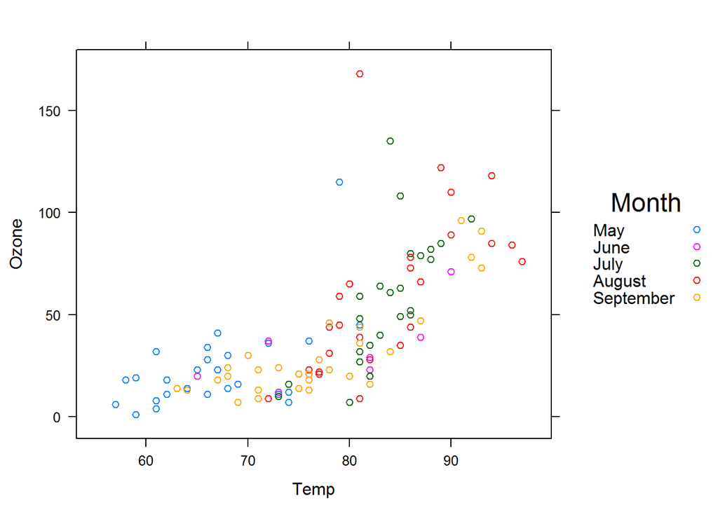

```r
xyplot(Ozone ~ Temp, airquality, groups = Month,
       # Complete the legend spec
       auto.key = list(space = "right",
                       title = "Month",
                       text = month.name[5:9]))
```

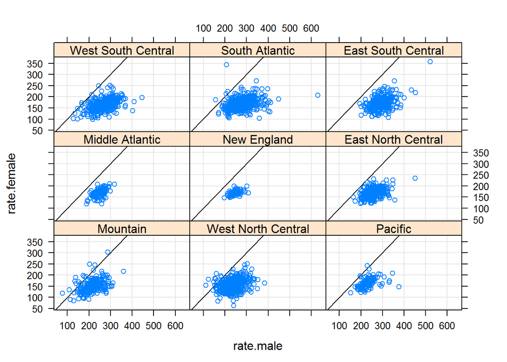

```r
USCancerRates <- USCancerRates %>%
    mutate(division=state.division[match(state, state.name)])

# Create 'division.ordered' by reordering levels
USCancerRates <-
  mutate(USCancerRates,
         division.ordered = reorder(division,
                                    rate.male + rate.female,
                                    mean, na.rm = TRUE))

# Create conditioned scatter plot
xyplot(rate.female ~ rate.male | division.ordered,
       data = USCancerRates,
       # Add reference grid
       grid = TRUE,
       # Add reference line
       abline = c(0, 1))
```

```r
# Levels of division.ordered
levels(USCancerRates$division.ordered)
```

```
## [1] "Mountain"           "West North Central" "Pacific"
## [4] "Middle Atlantic"    "New England"        "East North Central"
## [7] "West South Central" "South Atlantic"     "East South Central"
```

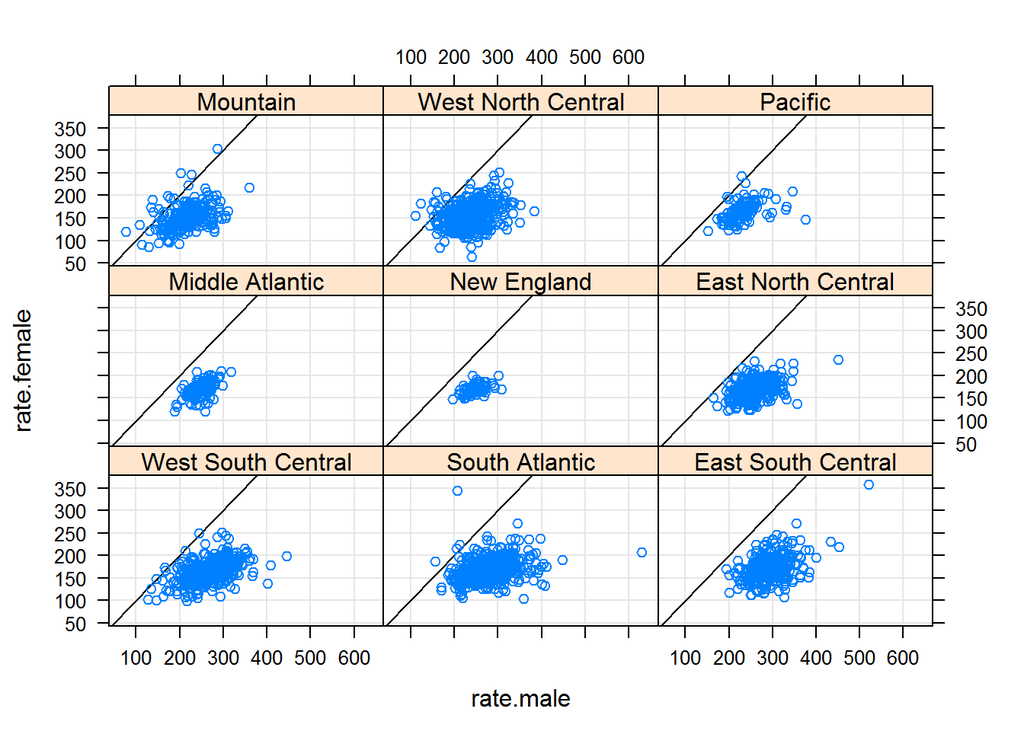

```r
# Specify the as.table argument
xyplot(rate.female ~ rate.male | division.ordered,
       data = USCancerRates,
       grid = TRUE, abline = c(0, 1),
       as.table=TRUE)
```

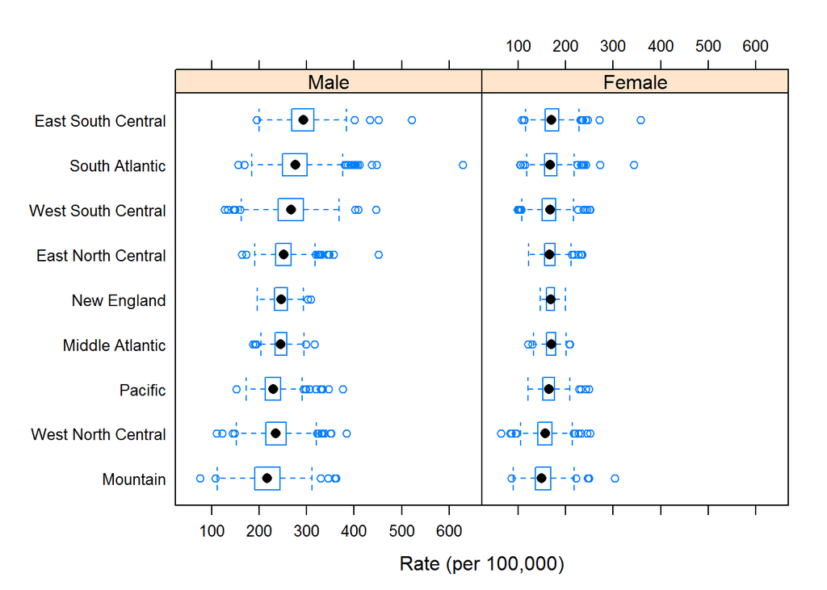

```r
# Create box-and-whisker plot
bwplot(division.ordered ~ rate.male + rate.female,
       data = USCancerRates,
       outer = TRUE,
       # Add a label for the x-axis
       xlab="Rate (per 100,000)",
       # Add strip labels
       strip = strip.custom(factor.levels = c("Male", "Female")))
```

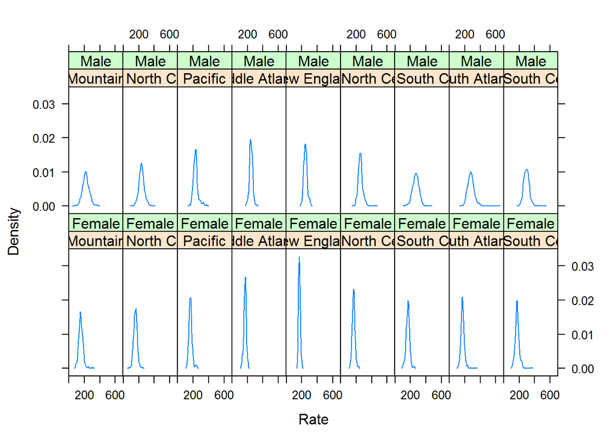

```r
# Create "trellis" object
tplot <-
    densityplot(~ rate.male + rate.female | division.ordered,
                data = USCancerRates, outer = TRUE,
                plot.points = FALSE, as.table = TRUE)

# Change names for the second dimension
dimnames(tplot)[[2]] <- c("Male", "Female")

# Update x-axis label and plot
update(tplot, xlab = "Rate")
```

```r
# Create "trellis" object
tplot <-
    densityplot(~ rate.male + rate.female | division.ordered,
                data = USCancerRates, outer = TRUE,
                plot.points = FALSE, as.table = TRUE)

# Inspect dimension
dim(tplot)
```

```
## [1] 9 2
```

```r
dimnames(tplot)
```

```
## $division.ordered
## [1] "Mountain"           "West North Central" "Pacific"
## [4] "Middle Atlantic"    "New England"        "East North Central"
## [7] "West South Central" "South Atlantic"     "East South Central"
##
## [[2]]
## [1] "rate.male"   "rate.female"
```

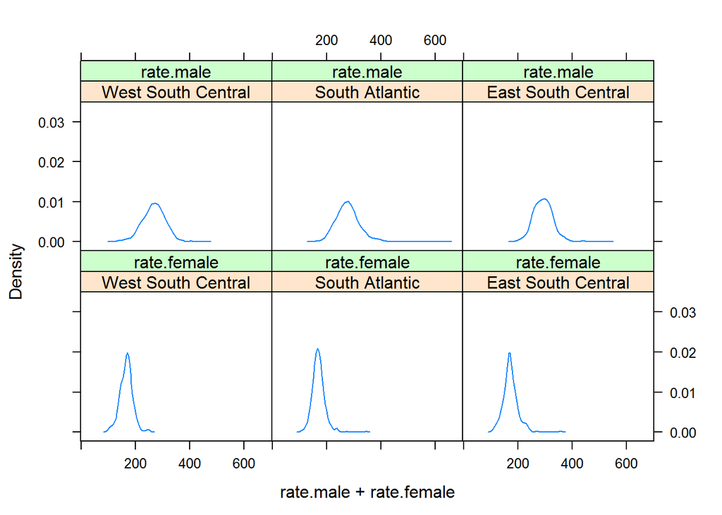

```r
# Select subset retaining only last three divisions
tplot[7:9, ]
```

Chapter 3 - Controlling scales and graphical parameters